# CORE WEBSITE INFORMATION

Urška Košir

Last update: 2021-11-10

### DEMOGRAPHICS GLOBAL SAMPLE

- Data presented here was collected between March 27, 2020 and 2021-09-21 07:06:05
- This data was collected from 67227 people.
- **Self-reported** average age of participants: 42.9 years old.
- Participant ages ranged from 8 to 120 years old

### DEMOGRAPHICS breakdown

Please include categories “other”, “prefer not to answer” and “NA” = missing information somewhere either below each plot or at the bottom of the page.

This is to make the data presentation more transparent and show how many people are represented in the plots.

#### SEX

| sex | n |
| --- | --- |
| male | 15410 |
| female | 38367 |
| other | 183 |
| prefer not to answer | 433 |
| NA | 12834 |

| wave | n |
| --- | --- |
| 1 | 3755 |
| 2 | 1258 |
| 3 | 889 |
| 4 | 743 |
| 5 | 607 |
| 6 | 566 |
| 7 | 322 |
| 8 | 451 |
| 9 | 215 |
| 10 | 209 |
| 11 | 127 |

#### AGE

| age_group | n |
| --- | --- |
| 26 - 50y | 26187 |
| over 51 | 17858 |
| under 25 | 9600 |
| NA | 13582 |

#### AREA

| area | n |
| --- | --- |
| rural | 5490 |
| suburban | 10610 |
| urban | 26188 |
| prefer not to answer | 214 |
| NA | 24725 |

#### INCOME

| hoinc | n |
| --- | --- |
| bottom 3rd | 5471 |
| middle 3rd | 21188 |
| top 3rd | 10983 |
| prefer not to answer | 4609 |
| NA | 24976 |

#### EDUCATION

| edu | n |
| --- | --- |
| primary | 224 |
| secondary | 8682 |
| college | 15363 |
| graduate | 19301 |
| never been | 22 |
| prefer not to answer | 284 |
| NA | 23351 |

#### EMPLOYMENT

| employment | n |
| --- | --- |
| no | 21011 |
| yes | 22314 |
| prefer not to answer | 858 |
| NA | 23044 |

### Cumulative count to add to the plot

| Year-Month | N |
| --- | --- |
| 2020-03 | 4790 |
| 2020-04 | 23362 |
| 2020-05 | 11699 |
| 2020-06 | 5079 |
| 2020-07 | 5484 |
| 2020-08 | 2584 |
| 2020-09 | 1884 |
| 2020-10 | 1723 |
| 2020-11 | 2143 |
| 2020-12 | 1543 |
| 2021-01 | 1075 |
| 2021-02 | 1779 |
| 2021-03 | 1004 |
| 2021-04 | 823 |
| 2021-05 | 1359 |
| 2021-06 | 661 |
| 2021-07 | 192 |
| 2021-08 | 41 |
| 2021-09 | 2 |

## HEALTH BEHAVIOURS

*value of 1 in the column “Most of the time” indicates that it is only people who responded most of the time

### HAND WASHING

| Year-Month | Measure | N yes to most time | Sum of all responses | % saying most of the time |
| --- | --- | --- | --- | --- |
| 2020-03 | hand_washing | 2933 | 3125 | 93.85600 |
| 2020-04 | hand_washing | 15644 | 16866 | 92.75465 |
| 2020-05 | hand_washing | 7624 | 9046 | 84.28034 |
| 2020-06 | hand_washing | 3012 | 3721 | 80.94598 |
| 2020-07 | hand_washing | 3186 | 3842 | 82.92556 |
| 2020-08 | hand_washing | 1215 | 1886 | 64.42206 |
| 2020-09 | hand_washing | 1183 | 1427 | 82.90119 |
| 2020-10 | hand_washing | 1053 | 1246 | 84.51043 |
| 2020-11 | hand_washing | 1384 | 1607 | 86.12321 |
| 2020-12 | hand_washing | 1130 | 1289 | 87.66486 |
| 2021-01 | hand_washing | 840 | 916 | 91.70306 |
| 2021-02 | hand_washing | 1252 | 1416 | 88.41808 |
| 2021-03 | hand_washing | 706 | 798 | 88.47118 |
| 2021-04 | hand_washing | 605 | 695 | 87.05036 |
| 2021-05 | hand_washing | 989 | 1158 | 85.40587 |
| 2021-06 | hand_washing | 455 | 550 | 82.72727 |
| 2021-07 | hand_washing | 101 | 146 | 69.17808 |
| 2021-08 | hand_washing | 20 | 26 | 76.92308 |

### FACE MASK

| Year-Month | Measure | N yes to most time | Sum of all responses | % saying most of the time |
| --- | --- | --- | --- | --- |
| 2020-03 | face_mask | 163 | 3055 | 5.335515 |
| 2020-04 | face_mask | 4518 | 16546 | 27.305693 |
| 2020-05 | face_mask | 5513 | 9030 | 61.052049 |
| 2020-06 | face_mask | 2443 | 3717 | 65.725047 |
| 2020-07 | face_mask | 2750 | 3843 | 71.558678 |
| 2020-08 | face_mask | 1764 | 1889 | 93.382742 |
| 2020-09 | face_mask | 1321 | 1429 | 92.442267 |
| 2020-10 | face_mask | 1189 | 1246 | 95.425361 |
| 2020-11 | face_mask | 1453 | 1608 | 90.360697 |
| 2020-12 | face_mask | 1212 | 1291 | 93.880713 |
| 2021-01 | face_mask | 889 | 915 | 97.158470 |
| 2021-02 | face_mask | 1338 | 1417 | 94.424841 |
| 2021-03 | face_mask | 744 | 799 | 93.116395 |
| 2021-04 | face_mask | 650 | 695 | 93.525180 |
| 2021-05 | face_mask | 1091 | 1159 | 94.132873 |
| 2021-06 | face_mask | 504 | 548 | 91.970803 |
| 2021-07 | face_mask | 89 | 146 | 60.958904 |
| 2021-08 | face_mask | 24 | 26 | 92.307692 |

### DISTANCING

| Year-Month | Measure | N yes to most time | Sum of all responses | % saying most of the time |
| --- | --- | --- | --- | --- |
| 2020-03 | distancing | 2635 | 3085 | 85.41329 |
| 2020-04 | distancing | 14602 | 16733 | 87.26469 |
| 2020-05 | distancing | 7434 | 9035 | 82.28002 |
| 2020-06 | distancing | 2813 | 3714 | 75.74044 |
| 2020-07 | distancing | 3150 | 3844 | 81.94589 |
| 2020-08 | distancing | 1369 | 1882 | 72.74176 |
| 2020-09 | distancing | 1062 | 1427 | 74.42186 |
| 2020-10 | distancing | 984 | 1246 | 78.97271 |
| 2020-11 | distancing | 1174 | 1610 | 72.91925 |
| 2020-12 | distancing | 992 | 1290 | 76.89922 |
| 2021-01 | distancing | 798 | 915 | 87.21311 |
| 2021-02 | distancing | 1106 | 1417 | 78.05222 |
| 2021-03 | distancing | 604 | 799 | 75.59449 |
| 2021-04 | distancing | 500 | 693 | 72.15007 |
| 2021-05 | distancing | 862 | 1160 | 74.31034 |
| 2021-06 | distancing | 345 | 550 | 62.72727 |
| 2021-07 | distancing | 61 | 146 | 41.78082 |
| 2021-08 | distancing | 19 | 26 | 73.07692 |

### Large gathering

| Year-Month | Measure | N yes to most time | Sum of all responses | % saying most of the time |
| --- | --- | --- | --- | --- |
| 2020-03 | large_gathering | 3042 | 3136 | 97.00255 |
| 2020-04 | large_gathering | 15855 | 16886 | 93.89435 |
| 2020-05 | large_gathering | 312 | 338 | 92.30769 |
| 2020-07 | large_gathering | 904 | 1038 | 87.09056 |
| 2020-08 | large_gathering | 1596 | 1888 | 84.53390 |
| 2020-09 | large_gathering | 1185 | 1430 | 82.86713 |
| 2020-10 | large_gathering | 1073 | 1247 | 86.04651 |
| 2020-11 | large_gathering | 1380 | 1609 | 85.76756 |
| 2020-12 | large_gathering | 1097 | 1290 | 85.03876 |
| 2021-01 | large_gathering | 790 | 915 | 86.33880 |
| 2021-02 | large_gathering | 1217 | 1416 | 85.94633 |
| 2021-03 | large_gathering | 654 | 800 | 81.75000 |
| 2021-04 | large_gathering | 558 | 695 | 80.28777 |
| 2021-05 | large_gathering | 956 | 1161 | 82.34281 |
| 2021-06 | large_gathering | 101 | 138 | 73.18841 |

| Year-Month | Measure | N yes to most time | Sum of all responses | % saying most of the time |
| --- | --- | --- | --- | --- |
| 2020-07 | all_gathering | 476 | 1038 | 45.85742 |
| 2020-08 | all_gathering | 840 | 1888 | 44.49153 |
| 2020-09 | all_gathering | 602 | 1430 | 42.09790 |
| 2020-10 | all_gathering | 652 | 1247 | 52.28549 |
| 2020-11 | all_gathering | 777 | 1609 | 48.29086 |
| 2020-12 | all_gathering | 648 | 1290 | 50.23256 |
| 2021-01 | all_gathering | 621 | 915 | 67.86885 |
| 2021-02 | all_gathering | 786 | 1416 | 55.50847 |
| 2021-03 | all_gathering | 418 | 800 | 52.25000 |
| 2021-04 | all_gathering | 320 | 695 | 46.04317 |
| 2021-05 | all_gathering | 528 | 1161 | 45.47804 |
| 2021-06 | all_gathering | 45 | 413 | 10.89588 |

### SMALL gathering

| Year-Month | Measure | N yes to most time | Sum of all responses | % saying most of the time |
| --- | --- | --- | --- | --- |
| 2020-07 | small_gathering | 484 | 1037 | 46.67310 |
| 2020-08 | small_gathering | 861 | 1888 | 45.60381 |
| 2020-09 | small_gathering | 626 | 1430 | 43.77622 |
| 2020-10 | small_gathering | 677 | 1248 | 54.24679 |
| 2020-11 | small_gathering | 800 | 1610 | 49.68944 |
| 2020-12 | small_gathering | 671 | 1290 | 52.01550 |
| 2021-01 | small_gathering | 662 | 915 | 72.34973 |
| 2021-02 | small_gathering | 820 | 1416 | 57.90960 |
| 2021-03 | small_gathering | 437 | 800 | 54.62500 |
| 2021-04 | small_gathering | 329 | 695 | 47.33813 |
| 2021-05 | small_gathering | 549 | 1161 | 47.28682 |
| 2021-06 | small_gathering | 183 | 550 | 33.27273 |
| 2021-07 | small_gathering | 36 | 146 | 24.65753 |
| 2021-08 | small_gathering | 9 | 26 | 34.61538 |

### Plots

See the inconsistencies in gatherings

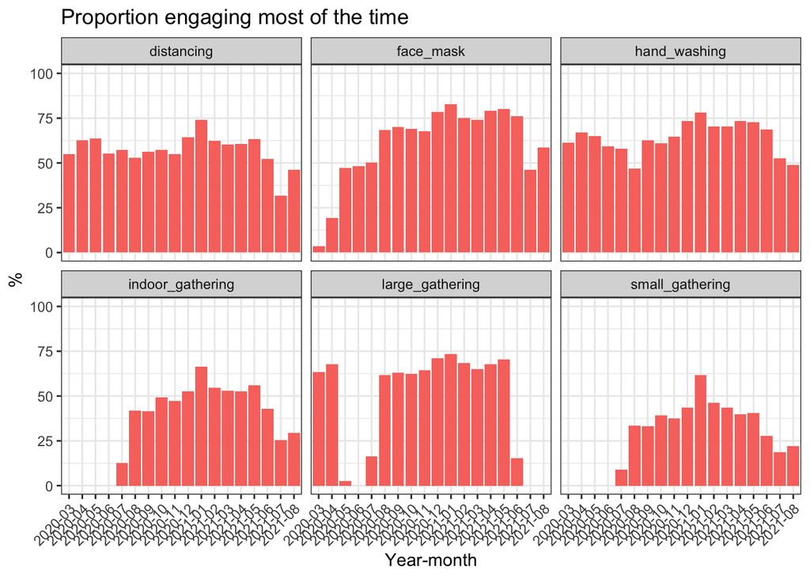

## QUARANTINE AFTER TRAVEL, wave 1 - 9 (“actfreq_sq009”)

| Month | Response category | N | Proportion |
| --- | --- | --- | --- |
| 2020-03 | Most time | 1080 | 87.10 |
| 2020-03 | Other | 160 | 12.90 |
| 2020-04 | Most time | 6565 | 80.83 |
| 2020-04 | Other | 1557 | 19.17 |
| 2020-05 | Most time | 3490 | 86.05 |
| 2020-05 | Other | 566 | 13.95 |
| 2020-06 | Most time | 1170 | 79.92 |
| 2020-06 | Other | 294 | 20.08 |
| 2020-07 | Most time | 1056 | 85.44 |
| 2020-07 | Other | 180 | 14.56 |
| 2020-08 | Most time | 713 | 78.70 |
| 2020-08 | Other | 193 | 21.30 |
| 2020-09 | Most time | 409 | 74.77 |
| 2020-09 | Other | 138 | 25.23 |
| 2020-10 | Most time | 390 | 72.63 |
| 2020-10 | Other | 147 | 27.37 |
| 2020-11 | Most time | 453 | 70.45 |
| 2020-11 | Other | 190 | 29.55 |
| 2020-12 | Most time | 353 | 73.54 |
| 2020-12 | Other | 127 | 26.46 |
| 2021-01 | Most time | 244 | 85.92 |
| 2021-01 | Other | 40 | 14.08 |
| 2021-02 | Most time | 372 | 73.52 |
| 2021-02 | Other | 134 | 26.48 |
| 2021-03 | Most time | 220 | 71.20 |
| 2021-03 | Other | 89 | 28.80 |
| 2021-04 | Most time | 121 | 58.17 |
| 2021-04 | Other | 87 | 41.83 |
| 2021-05 | Most time | 261 | 64.13 |
| 2021-05 | Other | 146 | 35.87 |
| 2021-06 | Most time | 45 | 61.64 |
| 2021-06 | Other | 28 | 38.36 |
| 2021-07 | Most time | 1 | 100.00 |

## QUARANTINE AFTER EXPOSURE TO VIRUS, wave 1 - 9 (“actfreq_sq010”)

| Month | Response category | N | Proportion |
| --- | --- | --- | --- |
| 2020-03 | Most time | 1318 | 89.05 |
| 2020-03 | Other | 162 | 10.95 |
| 2020-04 | Most time | 7417 | 82.97 |
| 2020-04 | Other | 1522 | 17.03 |
| 2020-05 | Most time | 4075 | 90.62 |
| 2020-05 | Other | 422 | 9.38 |
| 2020-06 | Most time | 1501 | 88.04 |
| 2020-06 | Other | 204 | 11.96 |
| 2020-07 | Most time | 1419 | 91.14 |
| 2020-07 | Other | 138 | 8.86 |
| 2020-08 | Most time | 847 | 82.55 |
| 2020-08 | Other | 179 | 17.45 |
| 2020-09 | Most time | 573 | 86.04 |
| 2020-09 | Other | 93 | 13.96 |
| 2020-10 | Most time | 547 | 88.08 |
| 2020-10 | Other | 74 | 11.92 |
| 2020-11 | Most time | 758 | 87.03 |
| 2020-11 | Other | 113 | 12.97 |
| 2020-12 | Most time | 606 | 86.82 |
| 2020-12 | Other | 92 | 13.18 |
| 2021-01 | Most time | 402 | 95.04 |
| 2021-01 | Other | 21 | 4.96 |
| 2021-02 | Most time | 655 | 89.73 |
| 2021-02 | Other | 75 | 10.27 |
| 2021-03 | Most time | 412 | 87.85 |
| 2021-03 | Other | 57 | 12.15 |
| 2021-04 | Most time | 283 | 82.27 |
| 2021-04 | Other | 61 | 17.73 |
| 2021-05 | Most time | 524 | 86.90 |
| 2021-05 | Other | 79 | 13.10 |
| 2021-06 | Most time | 245 | 75.15 |
| 2021-06 | Other | 81 | 24.85 |
| 2021-07 | Most time | 39 | 57.35 |
| 2021-07 | Other | 29 | 42.65 |
| 2021-08 | Most time | 10 | 90.91 |
| 2021-08 | Other | 1 | 9.09 |

### A note from Jo

Very few responses for July, Aug, and Sept (192, 41, 2 respectively)

This arguably makes these new results a little less interesting (for instance, the overall demographics haven’t budged).

I’d like to propose new graphs — different visuals to offer a “fresh” look at the data.

The team may prefer using the same graphs.

- Q1: Should we be trying to make new results compelling?
- Q2: Is the team planning on using these new results for a specific meetings/date?

I will adjust the gameplan accordingly.